# Data Mining Assignment1

Fiona Fei

1/19/2022

#### 1. Use csv or caret data.

```r
df <- read.csv('GermanCredit.csv', header=TRUE)

#View(df)
```

#### 2. Build a regression model to predict variable “Amount” as a function of other variables (choose variables that you think are necessary and required to build a good model)

```r
#Create dummy variables for Class
df <- dummy_cols(df,select_columns = 'Class')
df <- subset (df, select = -c(Class))
lm1 = lm(Amount ~ ., data = df, na.action=na.omit)
#summary(lm1)
```

```r
#Eliminate variables with 'NA's in the summary above
df1 <- subset (df, select = -c(CheckingAccountStatus.none,CreditHistory.Critical,Purpose.Vacation,Purpose.Other,SavingsAccountBonds.Unknown,EmploymentDuration.Unemployed,Personal.Male.Married.Widowed,Personal.Female.Single,OtherDebtorsGuarantors.Guarantor,Property.Unknown,OtherInstallmentPlans.None,Housing.ForFree,Job.Management.SelfEmp.HighlyQualified,Class_Good ))
#df1
```

```r
#Create lm2 with updated variables
lm2 = lm(Amount ~ .-1, data = df1)
summary(lm2)
```

```
##
## Call:
## lm(formula = Amount ~ . - 1, data = df1)
##
## Residuals:
##     Min      1Q  Median      3Q     Max
## -5127.0 -1045.6  -150.7   726.1 11571.8
##
## Coefficients:
##                                      Estimate Std. Error t value Pr(>|t|)
## X                                      0.1355     0.2059   0.658  0.51080
## Duration                             132.3689     5.5414  23.887  < 2e-16 ***
## InstallmentRatePercentage           -733.7757    55.6093 -13.195  < 2e-16 ***
## ResidenceDuration                     25.1118    60.7265   0.414  0.67932
## Age                                   17.8210     6.0521   2.945  0.00331 **
## NumberExistingCredits                260.3499   127.6819   2.039  0.04172 *
## NumberPeopleMaintenance               63.5442   173.0379   0.367  0.71353
## Telephone                           -448.9350   137.1093  -3.274  0.00110 **
## ForeignWorker                        343.9879   316.5504   1.087  0.27746
## CheckingAccountStatus.lt.0          -102.4463   165.1510  -0.620  0.53520
## CheckingAccountStatus.0.to.200       357.0031   157.0671   2.273  0.02325 *
## CheckingAccountStatus.gt.200        -560.3252   259.0192  -2.163  0.03077 *
## CreditHistory.NoCredit.AllPaid       873.6582   335.3709   2.605  0.00933 **
## CreditHistory.ThisBank.AllPaid       107.6906   324.5244   0.332  0.74008
## CreditHistory.PaidDuly               231.3206   166.1779   1.392  0.16425
## CreditHistory.Delay                  197.8988   237.8325   0.832  0.40557
## Purpose.NewCar                       440.9958   487.3431   0.905  0.36575
## Purpose.UsedCar                     1214.3345   496.5547   2.446  0.01464 *
## Purpose.Furniture.Equipment          397.8000   496.2362   0.802  0.42296
## Purpose.Radio.Television             174.5519   491.1492   0.355  0.72237
## Purpose.DomesticAppliance           -323.8613   735.6227  -0.440  0.65985
## Purpose.Repairs                      414.4315   631.1704   0.657  0.51159
## Purpose.Education                    259.0249   550.1107   0.471  0.63785
## Purpose.Retraining                   111.9871   796.9205   0.141  0.88828
## Purpose.Business                     105.9689   518.1539   0.205  0.83800
## SavingsAccountBonds.lt.100          -142.5876   163.8387  -0.870  0.38436
## SavingsAccountBonds.100.to.500      -381.7469   234.3870  -1.629  0.10371
## SavingsAccountBonds.500.to.1000     -497.1091   275.2240  -1.806  0.07120 .
## SavingsAccountBonds.gt.1000         -287.7892   307.7865  -0.935  0.35001
## EmploymentDuration.lt.1              618.9298   315.7293   1.960  0.05025 .
```

[output cut: 10 more lines]

```
## Property.CarOther                   -544.4132   282.9903  -1.924  0.05468 .
## OtherInstallmentPlans.Bank           -24.5808   180.9526  -0.136  0.89198
## OtherInstallmentPlans.Stores         -78.0047   290.5193  -0.269  0.78837
## Housing.Rent                         627.7326   331.1702   1.895  0.05833 .
## Housing.Own                          556.0176   314.8216   1.766  0.07769 .
## Job.UnemployedUnskilled            -1269.4568   470.2224  -2.700  0.00706 **
## Job.UnskilledResident              -1255.2782   247.7053  -5.068 4.84e-07 ***
## Job.SkilledEmployee                -1241.3277   200.5709  -6.189 8.99e-10 ***
## Class_Bad                            260.2637   149.8270   1.737  0.08269 .
## ---
## Signif. codes:  0 '***' 0.001 '**' 0.01 '*' 0.05 '.' 0.1 ' ' 1
##
## Residual standard error: 1856 on 951 degrees of freedom
## Multiple R-squared:  0.8245, Adjusted R-squared:  0.8154
## F-statistic: 91.15 on 49 and 951 DF,  p-value: < 2.2e-16
```

```r
#Count the total number of rows and columns of new df1
nrow(df1)
```

```
## [1] 1000
```

```r
ncol(df1)
```

```
## [1] 50
```

```r
#Create coefficient dataframe
coef <- data.frame(matrix(ncol = 49, nrow = 1000))
colnames(coef) <- names(lm2$coefficients)
#Create r^2 dataframe
rsqr <- data.frame(matrix(ncol = 3, nrow = 1000))
colnames(rsqr) <- c("R_Square_Train", "R_Square_Test", "Percent_Decrease")
```

#### 3. Repeat the following steps 1000 times (for loop):

```r
#df2 <- subset (df1, select = -c(Amount))
for(i in 1:1000) {
#split sample into train and test using 632:328 ratio
dt = sort(sample(nrow(df1), nrow(df1)*.632))
train<-df1[dt,]
test<-df1[-dt,]
test_1 <- subset(test,select = c(Amount))
#create linear model using train data with Amount as the dependent variable.
lr = lm(Amount ~ .-1, data = train)
#save r squared in training
rsqr[i,1] = summary(lr)$r.squared
#save coefficients
coef[i,] = lr$coefficients
#save r squared in holdout predictions.
test_r = cor(test$Amount, predict(lr, newdata = test))^2
rsqr[i,2] = test_r

}
```

#### 4. Pick 3 variables and plot the distribution of its coefficients.

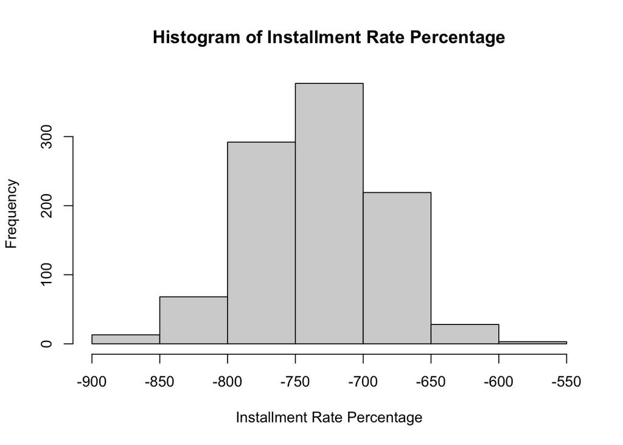

```r
#Installment Rate Percentage
x1 <- coef$InstallmentRatePercentage
h<-hist(x1, breaks=10, xlab="Installment Rate Percentage",
   main="Histogram of Installment Rate Percentage")
```

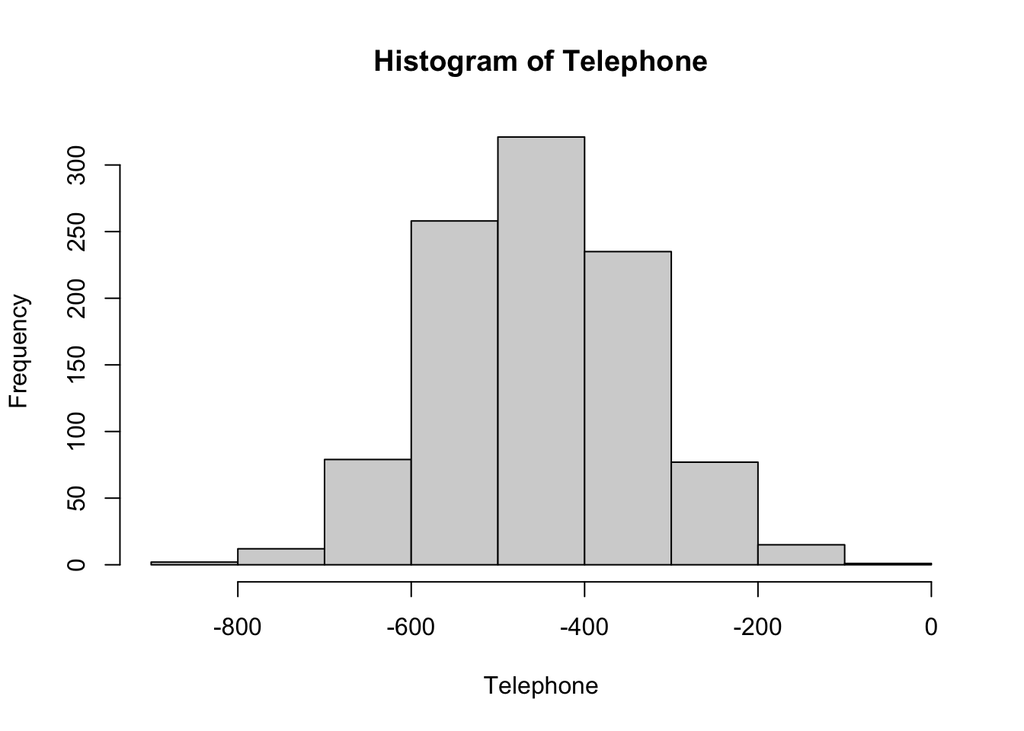

```r
# Telephone
x2 <- coef$Telephone
h<-hist(x2, breaks=10, xlab="Telephone",
   main="Histogram of Telephone")
```

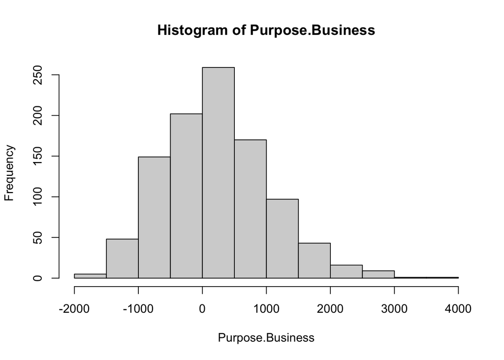

```r
#Purpose.Business
x3 <- coef$Purpose.Business
h<-hist(x3, breaks=10, xlab="Purpose.Business",
   main="Histogram of Purpose.Business")
```

#### 5. Plot distribution of R Squared in train

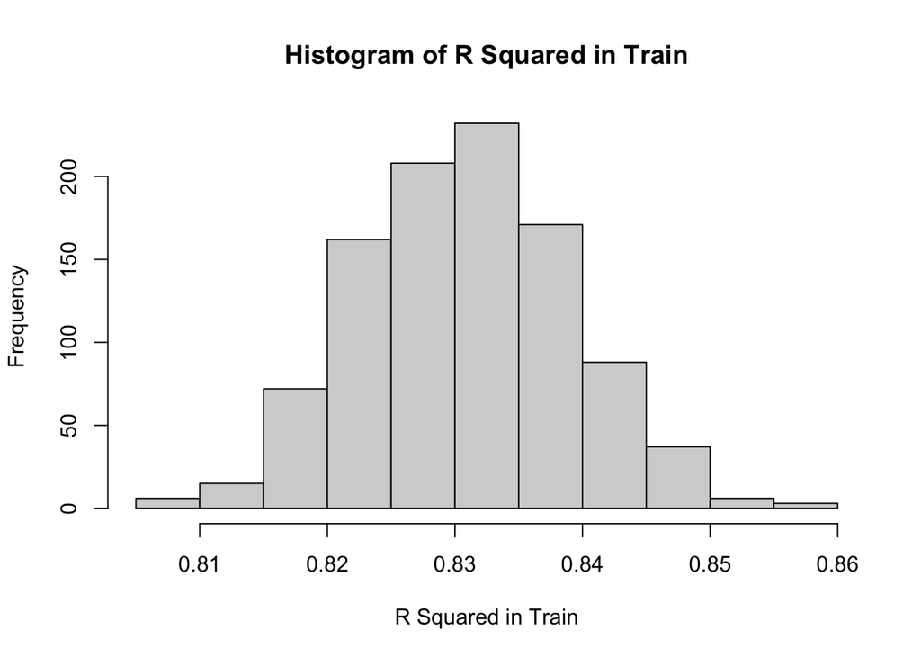

```r
#R squared in Train
x4 <- rsqr$R_Square_Train
h<-hist(x4, breaks=10, xlab="R Squared in Train",
   main="Histogram of R Squared in Train")
```

#### 6. Calculate percentage decrease of R square from train to holdout.

```r
#percentage decrease of R square from train to holdout.
rsqr$Percent_Decrease <- ((rsqr$R_Square_Train - rsqr$R_Square_Test)/rsqr$R_Square_Train)*100
head(rsqr)
```

```
##   R_Square_Train R_Square_Test Percent_Decrease
## 1      0.8290415     0.5431859         34.48025
## 2      0.8200072     0.5515612         32.73703
## 3      0.8239879     0.5303064         35.64148
## 4      0.8228486     0.5247950         36.22216
## 5      0.8176366     0.5704360         30.23355
## 6      0.8410810     0.4812991         42.77613
```

#### Plot the distribution of percentage decrease of R square from train to holdout.

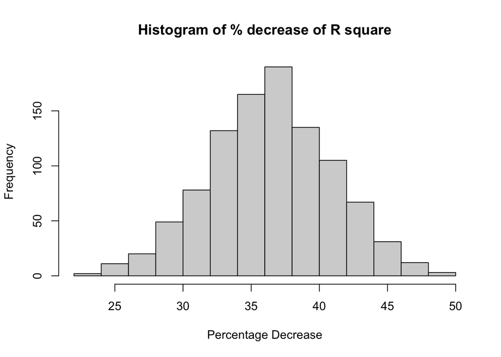

```r
x5 <- rsqr$Percent_Decrease
h<-hist(x5, breaks=10, xlab="Percentage Decrease",
   main="Histogram of % decrease of R square")
```

#### Interpretation:

##### Interpret the results of the above plots?

The above plots follows normal distribution’s bell shape with a little asymmetric on the two sides.

##### How would we hope/expect them to look?

We expect them to look like normal distributions with symmetric shapes.

##### Does this indicate a good result?

This indicate a good result because it shows that doing 1000 samples will help with concentrating the values.

##### What do these plots say about what we usually expect the R squared to be and how much R squared we usually expect to lose from Train to holdout?

We usually expect the trained R Squared to be greater than the test R Squared to show the percentage decrease of R Squared. These plots are great indications showing that the percentage decrease of R Squared are greater than 0. Based on the histogram, there are around 36% percent of R Squared we expected to lose from train to holdout.

#### 7. Calculate the mean of each coefficient.

```r
#Mean of each coefficient
#df2 <- subset (df1, select = -c(Amount))
coef_mean = colMeans(coef)
head(coef_mean)
```

```
##                         X                  Duration InstallmentRatePercentage
##                 0.1363244               131.8181946              -734.1575420
##         ResidenceDuration                       Age     NumberExistingCredits
##                24.6569960                17.4101068               252.7644503
```

```r
#Standard Deviation of each coefficient
coef_sd = sapply(df1, sd)
head(coef_sd)
```

```
##                         X                  Duration                    Amount
##                288.819436                 12.058814               2822.736876
## InstallmentRatePercentage         ResidenceDuration                       Age
##                  1.118715                  1.103718                 11.375469
```

#### 9. Compare the means of the 1000 coefficients to the coefficients from the model created in step 2 created using the entire sample. Show the percentage difference

```r
full_coef = lm2$coefficients

head(full_coef)
```

```
##                         X                  Duration InstallmentRatePercentage
##                 0.1354682               132.3689486              -733.7756574
##         ResidenceDuration                       Age     NumberExistingCredits
##                25.1117655                17.8209947               260.3499440
```

```r
#Mean of full sample coefficients and percentage difference.
#library(remotes)
mean_diff <- data.frame(coef_mean, lm2$coefficients, (((coef_mean - lm2$coefficients)/coef_mean)*100))
colnames(mean_diff) <- c('Repeat_Mean','Full_Model_Mean','Percentage_Diff')
head(mean_diff)
```

```
##                            Repeat_Mean Full_Model_Mean Percentage_Diff
## X                            0.1363244       0.1354682      0.62803796
## Duration                   131.8181946     132.3689486     -0.41781336
## InstallmentRatePercentage -734.1575420    -733.7756574      0.05201671
## ResidenceDuration           24.6569960      25.1117655     -1.84438346
## Age                         17.4101068      17.8209947     -2.36005408
## NumberExistingCredits      252.7644503     260.3499440     -3.00101290
```

### Confidence Intervals

#### 10. Using method of choice, calculate CI for each coefficient from the repeated sample model.

```r
#Sort dataframe in order
order_df <- apply(coef, 2, sort, decreasing=F)
#Only look at row 25 to 975.
order_df = coef[25:975,]
#View(order_df)
```

#### Calculate the width of the CI

```r
#Interval Width of 1000 values
rep_model_width = (order_df[1,] - order_df[951,])*sqrt(.632)
rep_model_width = t(rep_model_width)
head(rep_model_width)
```

```
##                                     25
## X                          -0.09836516
## Duration                    5.73600733
## InstallmentRatePercentage -89.57130311
## ResidenceDuration           9.33710415
## Age                        -0.23211072
## NumberExistingCredits     133.65012057
```

#### 11. Calculate CI for full model using confint function.

```r
#Interval Width of single model.
ci_single = confint(lm2, level = 0.95)
full_model_width = (ci_single[,2]-ci_single[,1])
head(full_model_width)
```

```
##                         X                  Duration InstallmentRatePercentage
##                 0.8082486                21.7497561               218.2621708
##         ResidenceDuration                       Age     NumberExistingCredits
##               238.3468178                23.7541786               501.1415662
```

#### 12. Calculate how many of the repeated sample CI’s are tighter or broader than the full model CI’s.

```r
compare_width <- data.frame(rep_model_width, full_model_width)
colnames(compare_width) <- c('rep_model_width','full_model_width')
compare_width$Rep_vs_Full <- ifelse(compare_width$rep_model_width > compare_width$full_model_width, 'REP',
                ifelse(compare_width$rep_model_width < compare_width$full_model_width, 'FULL', 'SAME'))
head(compare_width)
```

```
##                           rep_model_width full_model_width Rep_vs_Full
## X                             -0.09836516        0.8082486        FULL
## Duration                       5.73600733       21.7497561        FULL
## InstallmentRatePercentage    -89.57130311      218.2621708        FULL
## ResidenceDuration              9.33710415      238.3468178        FULL
## Age                           -0.23211072       23.7541786        FULL
## NumberExistingCredits        133.65012057      501.1415662        FULL
```

```r
confidence_interval <- data.frame(t(order_df[1,]),t(order_df[951,]),rep_model_width,ci_single[,1],ci_single[,2],full_model_width)
colnames(confidence_interval) <- c('Rep_Model_Lower_Bound','Rep_Model_Higher_Bound','Rep_Model_Width','Full_Model_Lower_Bound','Full_Model_Higher_Bound','Full_Model_Width')
head(confidence_interval)
```

```
##                           Rep_Model_Lower_Bound Rep_Model_Higher_Bound
## X                                    -0.1744472            -0.05071499
## Duration                            133.3695717           126.15432548
## InstallmentRatePercentage          -836.2878682          -723.61733401
## ResidenceDuration                   -14.8686239           -26.61364131
## Age                                  17.3763842            17.66835310
## NumberExistingCredits               311.5989875           143.48230325
##                           Rep_Model_Width Full_Model_Lower_Bound
## X                             -0.09836516             -0.2686561
## Duration                       5.73600733            121.4940706
## InstallmentRatePercentage    -89.57130311           -842.9067428
## ResidenceDuration              9.33710415            -94.0616434
## Age                           -0.23211072              5.9439054
## NumberExistingCredits        133.65012057              9.7791610
##                           Full_Model_Higher_Bound Full_Model_Width
## X                                       0.5395925        0.8082486
## Duration                              143.2438266       21.7497561
## InstallmentRatePercentage            -624.6445720      218.2621708
## ResidenceDuration                     144.2851744      238.3468178
## Age                                    29.6980841       23.7541786
## NumberExistingCredits                 510.9207271      501.1415662
```

#### 13. Interpret results.

##### How about the confidence intervals, how many were tighter or broader?

The confidence intervals in full model is always larger than the confidence intervals in repeated samples.

##### What does this say about each method?

The result indicates that using repeated samples can largely narrow down the confidence interval of the sample.

##### What if we tried doing 10,000 samples?

Doing 10,000 samples will keep narrowing down the confidence interval of the sample.

### Summary of Tables and Charts

#### 1. Histogram of 3 Coefficients (It is mentioned ALL coefficients in the assignment but 3 will do)

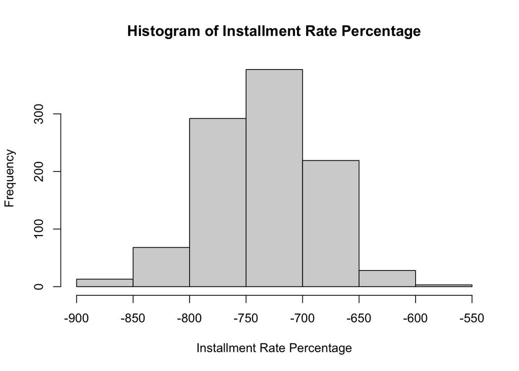

```r
#Installment Rate Percentage
x1 <- coef$InstallmentRatePercentage
h<-hist(x1, breaks=10, xlab="Installment Rate Percentage",
   main="Histogram of Installment Rate Percentage")
```

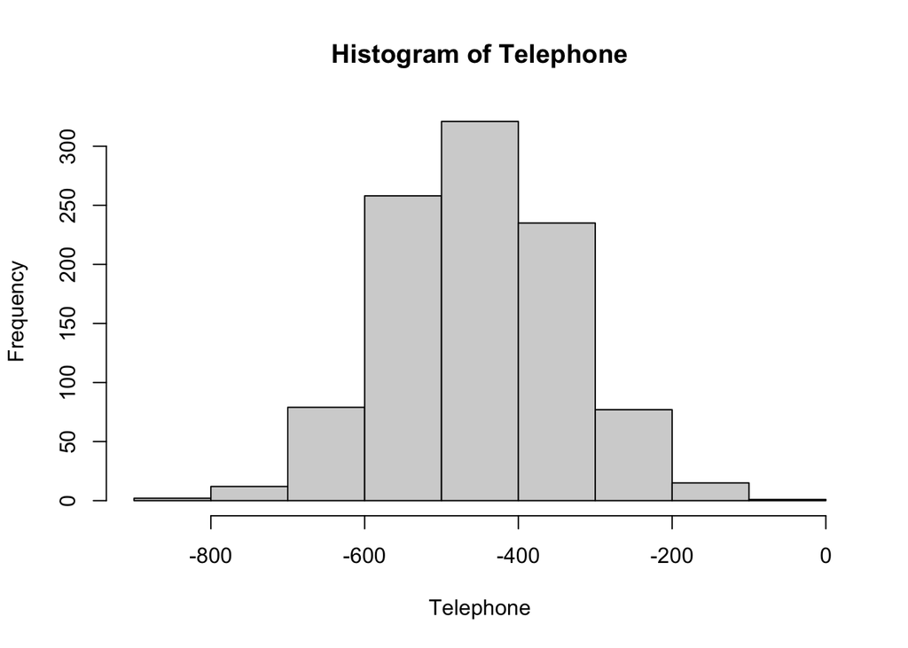

```r
# Telephone
x2 <- coef$Telephone
h<-hist(x2, breaks=10, xlab="Telephone",
   main="Histogram of Telephone")
```

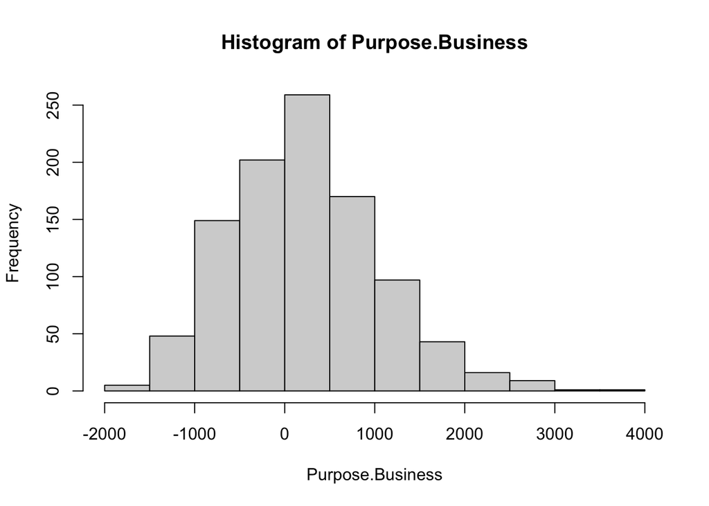

```r
#Purpose.Business
x3 <- coef$Purpose.Business
h<-hist(x3, breaks=10, xlab="Purpose.Business",
   main="Histogram of Purpose.Business")
```

#### 2. Histogram of Train R squared

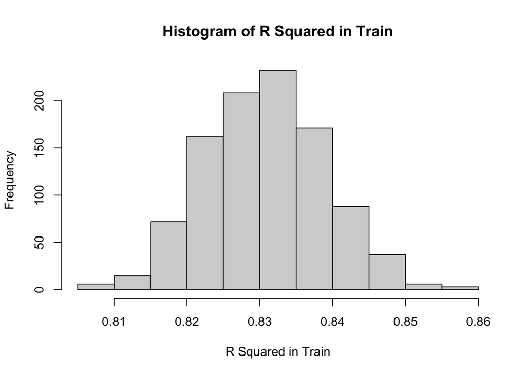

```r
#R squared in Train
x4 <- rsqr$R_Square_Train
h<-hist(x4, breaks=10, xlab="R Squared in Train",
   main="Histogram of R Squared in Train")
```

#### 3. Histogram of Percentage drop in R squared from train to test

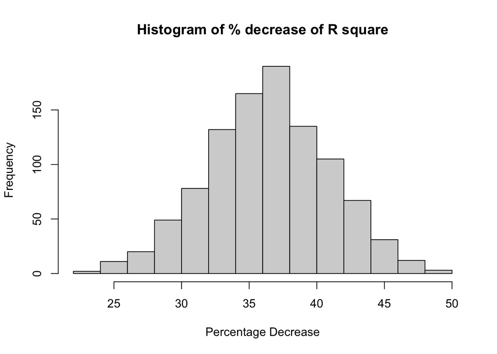

```r
x5 <- rsqr$Percent_Decrease
h<-hist(x5, breaks=10, xlab="Percentage Decrease",
   main="Histogram of % decrease of R square")
```

#### 4. Table of R square train, R square Holdout, Percentage drop

```r
head(rsqr)
```

```
##   R_Square_Train R_Square_Test Percent_Decrease
## 1      0.8290415     0.5431859         34.48025
## 2      0.8200072     0.5515612         32.73703
## 3      0.8239879     0.5303064         35.64148
## 4      0.8228486     0.5247950         36.22216
## 5      0.8176366     0.5704360         30.23355
## 6      0.8410810     0.4812991         42.77613
```

#### 5. Table of Mean of repeated sample coefficients, Mean of full sample coefficients, percentage difference.

```r
head(mean_diff,10)
```

```
##                             Repeat_Mean Full_Model_Mean Percentage_Diff
## X                             0.1363244       0.1354682      0.62803796
## Duration                    131.8181946     132.3689486     -0.41781336
## InstallmentRatePercentage  -734.1575420    -733.7756574      0.05201671
## ResidenceDuration            24.6569960      25.1117655     -1.84438346
## Age                          17.4101068      17.8209947     -2.36005408
## NumberExistingCredits       252.7644503     260.3499440     -3.00101290
## NumberPeopleMaintenance      53.5536086      63.5441674    -18.65524860
## Telephone                  -451.6118298    -448.9350036      0.59272721
## ForeignWorker               344.2793461     343.9878738      0.08466156
## CheckingAccountStatus.lt.0  -99.1971013    -102.4463280     -3.27552584
```

#### 6. Table of repeated sample lower bounds, upper bounds, scaled width and full sample lower bounds, upper bounds, and width.

```r
head(confidence_interval,10)
```

```
##                            Rep_Model_Lower_Bound Rep_Model_Higher_Bound
## X                                     -0.1744472            -0.05071499
## Duration                             133.3695717           126.15432548
## InstallmentRatePercentage           -836.2878682          -723.61733401
## ResidenceDuration                    -14.8686239           -26.61364131
## Age                                   17.3763842            17.66835310
## NumberExistingCredits                311.5989875           143.48230325
## NumberPeopleMaintenance              313.2219041           139.93513126
## Telephone                           -502.2539895          -524.47827843
## ForeignWorker                        673.6330251           186.81510124
## CheckingAccountStatus.lt.0          -108.2403237           -25.30021865
##                            Rep_Model_Width Full_Model_Lower_Bound
## X                              -0.09836516             -0.2686561
## Duration                        5.73600733            121.4940706
## InstallmentRatePercentage     -89.57130311           -842.9067428
## ResidenceDuration               9.33710415            -94.0616434
## Age                            -0.23211072              5.9439054
## NumberExistingCredits         133.65012057              9.7791610
## NumberPeopleMaintenance       137.76025974           -276.0359966
## Telephone                      17.66796028           -718.0066772
## ForeignWorker                 387.01259505           -277.2300940
## CheckingAccountStatus.lt.0    -65.93607942           -426.5487733
##                            Full_Model_Higher_Bound Full_Model_Width
## X                                        0.5395925        0.8082486
## Duration                               143.2438266       21.7497561
## InstallmentRatePercentage             -624.6445720      218.2621708
## ResidenceDuration                      144.2851744      238.3468178
## Age                                     29.6980841       23.7541786
## NumberExistingCredits                  510.9207271      501.1415662
## NumberPeopleMaintenance                403.1243313      679.1603279
## Telephone                             -179.8633301      538.1433471
## ForeignWorker                          965.2058416     1242.4359356
## CheckingAccountStatus.lt.0             221.6561173      648.2048906
```

#### 7. Number of CI tighter or broader.

```r
head(compare_width,10)
```

```
##                            rep_model_width full_model_width Rep_vs_Full
## X                              -0.09836516        0.8082486        FULL
## Duration                        5.73600733       21.7497561        FULL
## InstallmentRatePercentage     -89.57130311      218.2621708        FULL
## ResidenceDuration               9.33710415      238.3468178        FULL
## Age                            -0.23211072       23.7541786        FULL
## NumberExistingCredits         133.65012057      501.1415662        FULL
## NumberPeopleMaintenance       137.76025974      679.1603279        FULL
## Telephone                      17.66796028      538.1433471        FULL
## ForeignWorker                 387.01259505     1242.4359356        FULL
## CheckingAccountStatus.lt.0    -65.93607942      648.2048906        FULL
```